# Berkson’s Paradox and Trade-Offs

By: Andrew McKenzie

Date: First Published: 2012-12-30; Last Updated: 2023-01-08

- [Link back to the home page](https://andrewtmckenzie.com/)

## How Trade-Offs Relate to Selection

More generally, imagine that you have a decision to make and can choose only one option. You have many choices, each with two parameter values that you care about, which are independently sampled from a uniform distribution. The salient class will be those options that you’ll consider, because you wouldn’t even consider a choice if some other choice systematically dominates it.

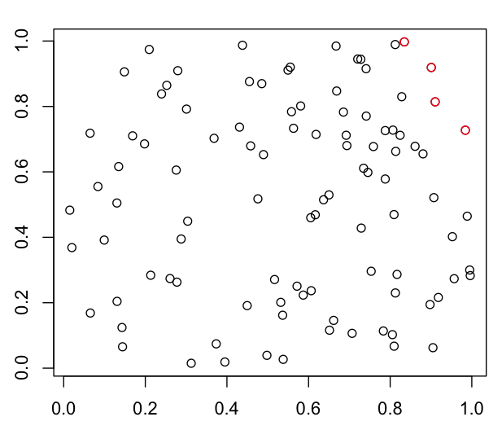

The red points in these uniform distributions are the ones you might care about if you’re trying to maximize these two variables

Just to be clear, note that the existence of a selection-based trade-off does not *imply* that the two variables are distributed independently of one another. My point is merely that the existence of a trade-off does not imply non-independence.

Berkson’s paradox says that two independent events can be made dependent by conditioning on a consequence of both of them. As an example, consider three events:

- A = Randomly Choose Between Integers 1 to 10,
- B = Randomly Choose Between Integers 1 to 10,
- C = A + B,

which establishes a causal network of A -> C <- B. Imagine that you only select triplets (A, B, C) such that C > 16. Although A and B are each chosen randomly, such a stratification on the levels of C will *induce* an inverse correlation between A and B. And this is exactly the sort of selection you impose upon possible choices when you make a decision that involves a trade-off.

## Conventionally Attractive vs Skilled Actors

Here is Manfred’s [example](http://lesswrong.com/lw/eri/taking_correlation_does_not_imply_causation_back/7k4c) (slightly edited):

> Conventionally attractive people are more likely to be hired as actors. Good actors are also more likely to be hired as actors. So if we look at “people who are actors,” then we’ll get people who are attractive but can’t really act, people who are attractive and can act, and people who can act and aren’t really attractive. If attractiveness and acting ability are independent, these three groups will be about equally full.

> Thus if we look at actors in general in our simple model, 2/3 of them will be attractive and 2/3 of them will be good actors. But of the ones who are attractive, only 1/2 will be good actors. So being attractive. is correlated with being a bad actor! Not because attractiveness rots your brain (a), or because acting well makes you ugly (b), and not because acting classes cause both good acting and non-attractiveness, or diet pills cause both beauty and bad acting (c). Instead, it’s just because how we picked actors made attractiveness and acting ability “compete for the same niche.”

Thus if you consider the set of Hollywood actors, you might conclude that conventionally attractive people are less likely to be able to actually act. But this observed relationship doesn’t mean that these two qualities are *intrinsically* inversely correlated. Instead, selection effects explain the relationship quite well.

## Sodium vs Sugar In Drinks

As an example with real data, consider the [macronutrients](http://en.wikipedia.org/wiki/Nutrient) in the set of Starbucks drinks circa 2008. In particular, compare the sugar content of a drink to its salt content ([the data now requires an e-mail request](http://www.factual.com/data-apis/places);[code](https://github.com/andymckenzie/Starbucks-Drinks)):

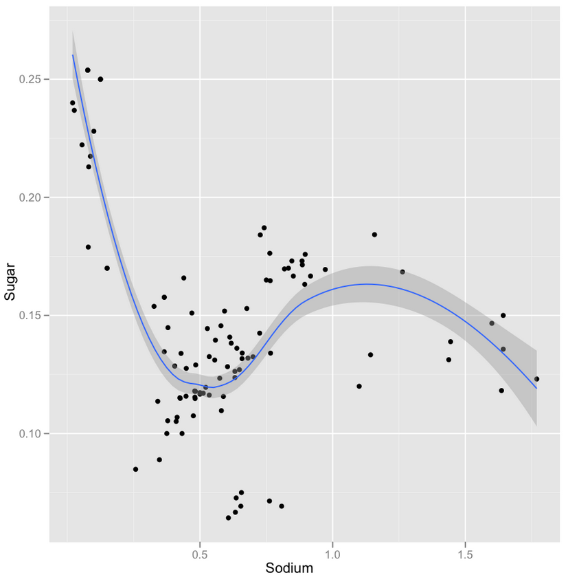

Starbucks drinks data

Although the relationship is far from perfect, the selection effect here is clear: in order to actually be bought, every drink needs to offer some sort of benefit to consumers. And consumers typically value taste. I expect that those drinks which are low on both of these categories offer something else, such as [catechins](http://en.wikipedia.org/wiki/Epigallocatechin_gallate).

## Using Berkson’s Paradox To Classify Trade-Offs

Many trade-offs are the result of a Berkson’s paradox-like selection bias. Still, there can still be trade-offs in the absence of selection. For example, consider the false alarm vs oversight trade-off, which can be parametrized in a [null hypothesis testing](http://en.wikipedia.org/wiki/Null_hypothesis) setting by the [p-value](http://en.wikipedia.org/wiki/P-value) threshold. No selection is necessary to invoke a trade-off between the rate of false positives and false negatives. Over the full range of both the type I error rate and the type II error rate, shifting the p-value threshold will have the same direction of effect.

Thus this is a property we can use to carve up trade-off space into two classes:

- trade-offs between two variables which are “intrinsically” mostly independent, but become dependent as a result of our selecting only a particular subset of them, or

- trade-offs between two variables which are dependent, to at least some degree, over their full range of possible values.

It also suggests that another potentially fruitful way of dividing the first set of trade-offs is to think about what type of process or agent is performing the selection.

**Acknowledgment**: Thanks to [Brian Potter](http://coarsegrained.wordpress.com/) for discussion related to this idea.